# Code_along_115_completed

This is to help 1. Reenforce the coding that we have gone over and 2. Help make a boring lecture slightly less boring

```r
colleges <- read.csv("https://remiller1450.github.io/data/Colleges2019_Complete.csv")

head(colleges) #look at the first few rows of data
```

```
##   X                         Name        City State Enrollment Private
## 1 1 Abilene Christian University     Abilene    TX       3524 Private
## 2 3           Adelphi University Garden City    NY       5307 Private
## 3 4               Adrian College      Adrian    MI       1781 Private
## 4 5      AdventHealth University     Orlando    FL       1166 Private
## 5 8     Alabama A & M University      Normal    AL       4990  Public
## 6 9     Alabama State University  Montgomery    AL       3903  Public
##        Region Adm_Rate ACT_median ACT_Q1 ACT_Q3  Cost Net_Tuition
## 1  South West   0.5696         24     21     21 48046       16177
## 2    Mid East   0.7418         25     22     22 49008       24971
## 3 Great Lakes   0.6481         23     19     19 51626       14136
## 4  South East   0.8689         20     18     18 24338       15360
## 5  South East   0.8986         18     16     16 22489        7413
## 6  South East   0.9774         18     16     16 21476       10160
##   Avg_Fac_Salary PercentFemale PercentWhite PercentBlack PercentHispanic
```

[output cut: 20 more lines]

```r
colnames(colleges) #and look at the column names
```

```
##  [1] "X"                    "Name"                 "City"
##  [4] "State"                "Enrollment"           "Private"
##  [7] "Region"               "Adm_Rate"             "ACT_median"
## [10] "ACT_Q1"               "ACT_Q3"               "Cost"
## [13] "Net_Tuition"          "Avg_Fac_Salary"       "PercentFemale"
## [16] "PercentWhite"         "PercentBlack"         "PercentHispanic"
## [19] "PercentAsian"         "FourYearComp_Males"   "FourYearComp_Females"
## [22] "Debt_median"          "Salary10yr_median"
```

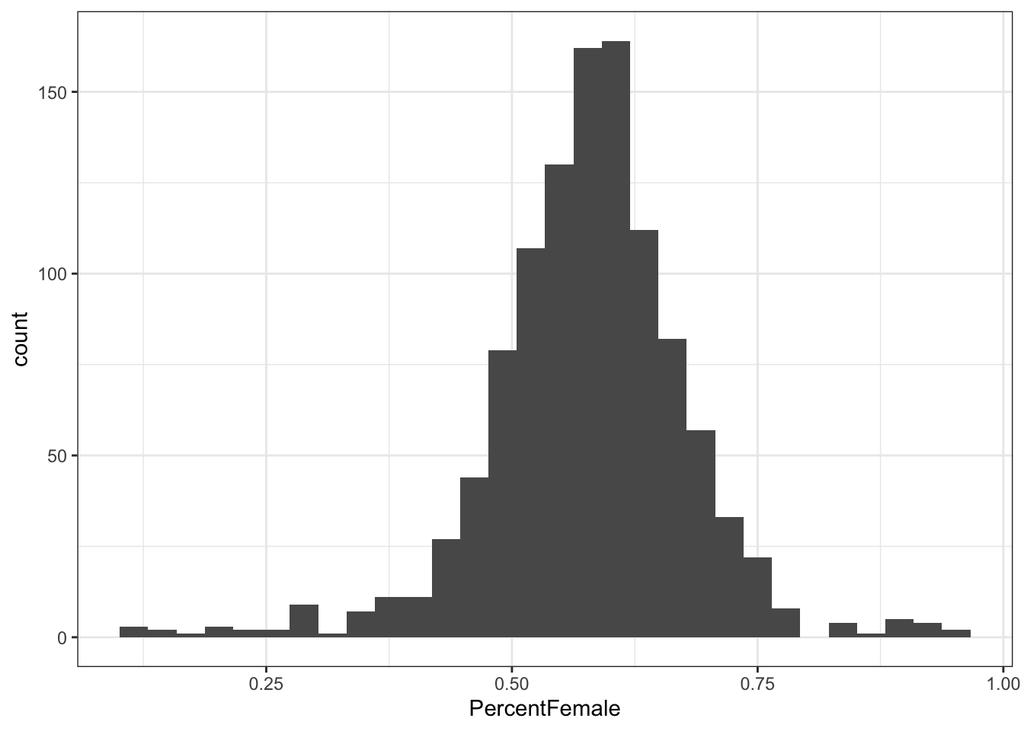

```r
library(ggplot2) #load ggplot2

ggplot(data = colleges, #data is colleges
       aes(x = PercentFemale)) + #and our x-axis is % female
  geom_histogram() + #and I want a histogram
  theme_bw() #with a black and white theme
```

```r
#summary summarizes information  about the thing fed to it
summary(colleges$PercentFemale)
```

```
##    Min. 1st Qu.  Median    Mean 3rd Qu.    Max.
##  0.1184  0.5268  0.5809  0.5778  0.6345  0.9550
```

```r
#in particular the five number summary (plus the mean)
#for a numeric vector
```

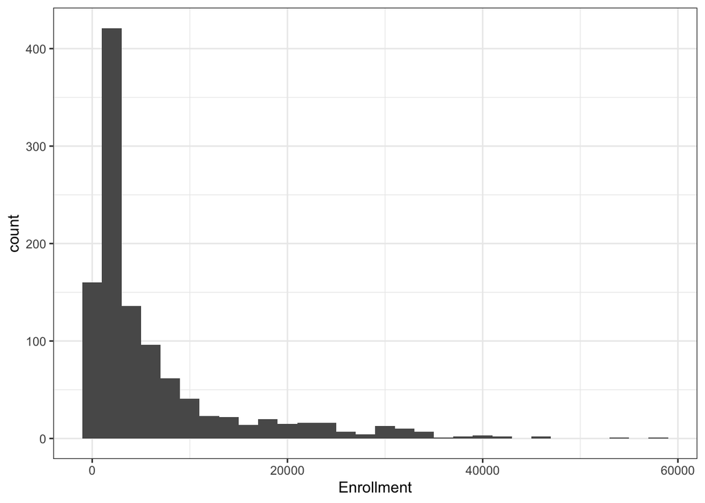

```r
#same battleplan as the above ones but now we switch
#out PercentFemale with Enrollment
ggplot(data = colleges,
       aes(x = Enrollment)) +
  geom_histogram() +
  theme_bw()
```

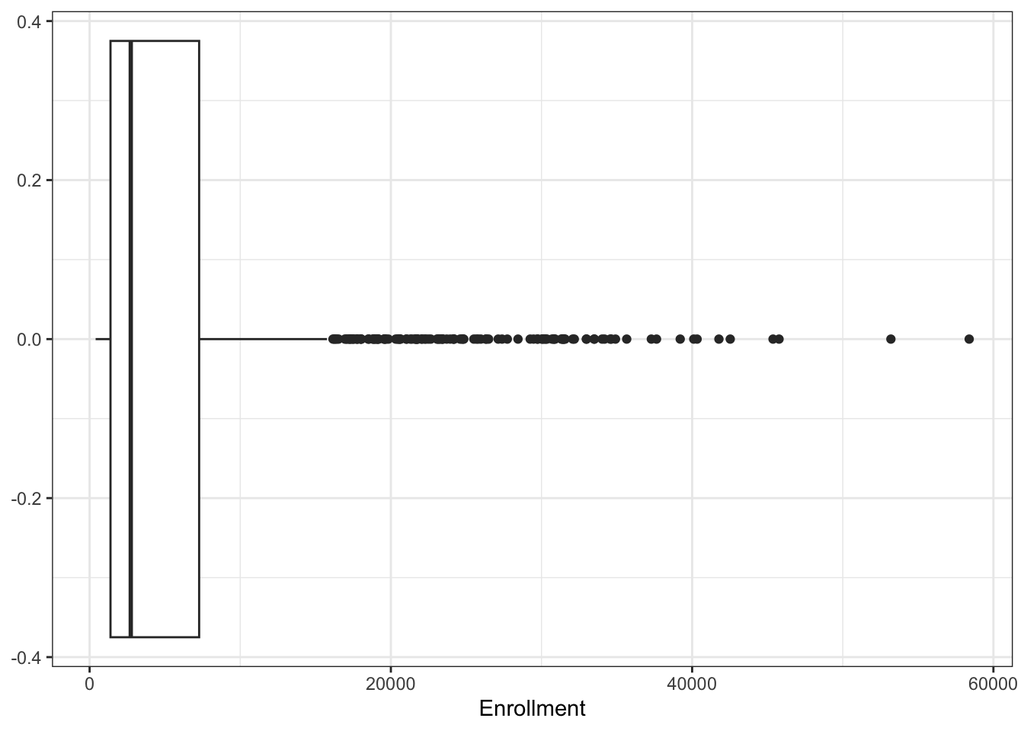

```r
#and this time I swithced out geom_histogram for geom_boxplot
ggplot(data = colleges,
       aes(x = Enrollment)) +
  geom_boxplot() +
  theme_bw()
```

```r
#summary summarizes information  about the thing fed to it
summary(colleges$Enrollment)
```

```
##    Min. 1st Qu.  Median    Mean 3rd Qu.    Max.
##     401    1388    2733    6241    7272   58392
```

# Enrollment on Log base 10 Scale

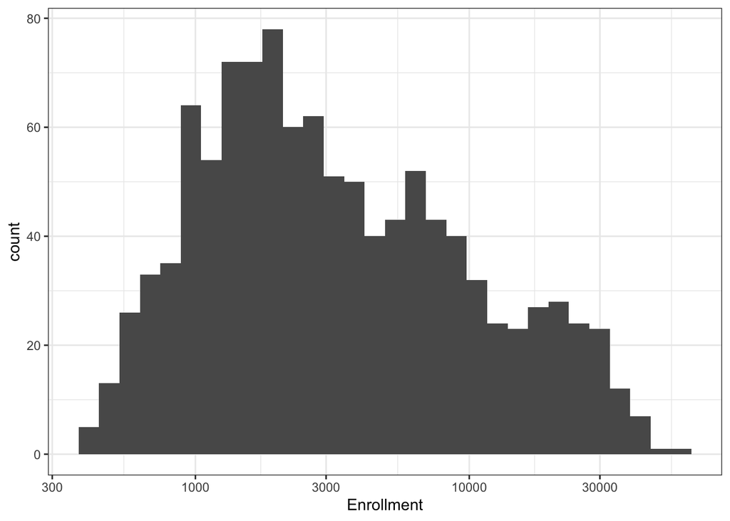

```r
#Very little has to change for the graph!
ggplot(data = colleges,
       aes(x = Enrollment)) +
  geom_histogram() +
  theme_bw() +
  scale_x_log10() #this is all we add, it says the x-axis is on
```

```r
                  #a log base 10 scale


#################
#Calculating the five number summary is a bit harder
#We have to make a new variable via a transformation


#new variable time
#We are creating a new column on our data set
#called enrollment_log10. We are then assigning
#the right hand side to that column.

#The right hand side is the function log() applied
#to our enrollment buuut we have changed the base
#of the log to base = 10 (instead of e)
colleges$enrollment_log10 <- log(colleges$Enrollment,
                                 base = 10)

colnames(colleges) #glance at the column names to see
```

```
##  [1] "X"                    "Name"                 "City"
##  [4] "State"                "Enrollment"           "Private"
##  [7] "Region"               "Adm_Rate"             "ACT_median"
## [10] "ACT_Q1"               "ACT_Q3"               "Cost"
## [13] "Net_Tuition"          "Avg_Fac_Salary"       "PercentFemale"
## [16] "PercentWhite"         "PercentBlack"         "PercentHispanic"
## [19] "PercentAsian"         "FourYearComp_Males"   "FourYearComp_Females"
## [22] "Debt_median"          "Salary10yr_median"    "enrollment_log10"
```

```r
#if our new variable is there

#and now we look at the summary
summary(colleges$enrollment_log10)
```

```
##    Min. 1st Qu.  Median    Mean 3rd Qu.    Max.
##   2.603   3.142   3.437   3.515   3.862   4.766
```

# Correcting the Wrong Axis

Shout out to your mentor for figuring out which variable was used to make the graph. It’s FourYearComp_Females it turns out. Hard to find the right variable but the code to make the graph isn’t hard at all

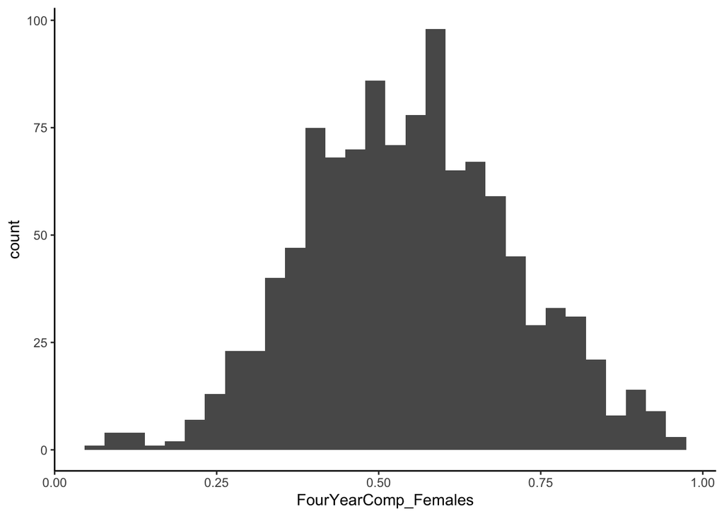

```r
ggplot(data = colleges,
       aes(x = FourYearComp_Females)) +
  geom_histogram() +
  theme_classic()
```

```r
summary(colleges$FourYearComp_Females)
```

```
##    Min. 1st Qu.  Median    Mean 3rd Qu.    Max.
## 0.06393 0.43263 0.54755 0.54808 0.65505 0.96078
```

# % White Enrollment

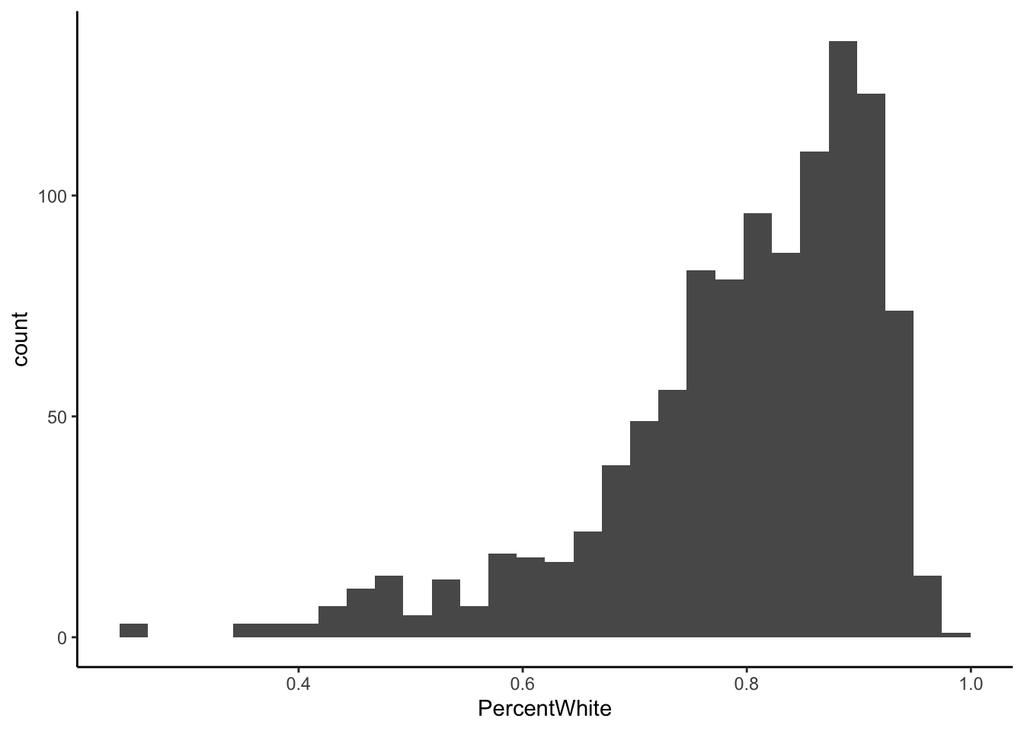

```r
ggplot(data = colleges,
       aes(x = PercentWhite)) +
  geom_histogram() +
  theme_classic()
```

```r
summary(colleges$PercentWhite)
```

```
##    Min. 1st Qu.  Median    Mean 3rd Qu.    Max.
##  0.2424  0.7369  0.8207  0.7942  0.8861  0.9762
```

# Median Debt

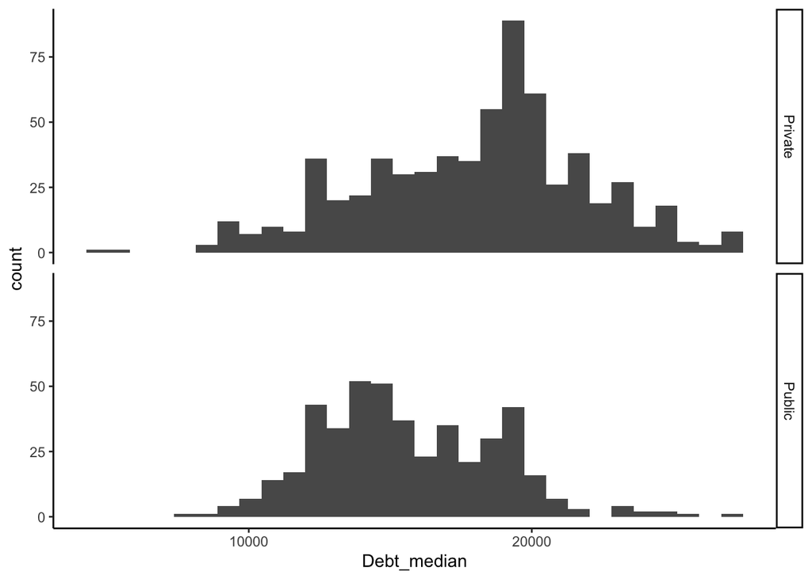

```r
ggplot(data = colleges,
       aes(x = Debt_median)) +
  geom_histogram(bins = 30) +
  theme_classic() +
  facet_grid(Private~.)
```

```r
summary(colleges$Debt_median)
```

```
##    Min. 1st Qu.  Median    Mean 3rd Qu.    Max.
##    4563   14250   17000   17045   19500   27000
```

```r
#aggregate your data. Much more info below
aggregate(Debt_median ~ Private,
          data = colleges,
          FUN = summary)
```

```
##   Private Debt_median.Min. Debt_median.1st Qu. Debt_median.Median
## 1 Private          4563.00            15322.00           18750.00
## 2  Public          7364.00            13167.25           15104.50
##   Debt_median.Mean Debt_median.3rd Qu. Debt_median.Max.
## 1         18027.71            20500.00         27000.00
## 2         15626.92            17816.25         27000.00
```

#Finding Grinnell COllege

```r
subset(colleges,
       Name == "Grinnell College") #Q1 and Q3 are the same....
```

```
##       X             Name     City State Enrollment Private Region Adm_Rate
## 314 497 Grinnell College Grinnell    IA       1683 Private Plains   0.2438
##     ACT_median ACT_Q1 ACT_Q3  Cost Net_Tuition Avg_Fac_Salary PercentFemale
## 314         32     30     30 65814       20369         101979     0.5348837
##     PercentWhite PercentBlack PercentHispanic PercentAsian FourYearComp_Males
## 314       0.7933       0.0971          0.0841         0.04          0.7413793
##     FourYearComp_Females Debt_median Salary10yr_median enrollment_log10
## 314            0.8372093       15000             49100         3.226084
```

```r
head(colleges)
```

```
##   X                         Name        City State Enrollment Private
## 1 1 Abilene Christian University     Abilene    TX       3524 Private
## 2 3           Adelphi University Garden City    NY       5307 Private
## 3 4               Adrian College      Adrian    MI       1781 Private
## 4 5      AdventHealth University     Orlando    FL       1166 Private
## 5 8     Alabama A & M University      Normal    AL       4990  Public
## 6 9     Alabama State University  Montgomery    AL       3903  Public
##        Region Adm_Rate ACT_median ACT_Q1 ACT_Q3  Cost Net_Tuition
## 1  South West   0.5696         24     21     21 48046       16177
## 2    Mid East   0.7418         25     22     22 49008       24971
## 3 Great Lakes   0.6481         23     19     19 51626       14136
## 4  South East   0.8689         20     18     18 24338       15360
## 5  South East   0.8986         18     16     16 22489        7413
## 6  South East   0.9774         18     16     16 21476       10160
##   Avg_Fac_Salary PercentFemale PercentWhite PercentBlack PercentHispanic
```

[output cut: 20 more lines]

```r
#several way to calculate if they are the same but
#since they are numeric lets be direct and subtract
colleges$ACT_Q1 - colleges$ACT_Q3
```

[output not shown]

# Five number summary for Enrollment by Private

We will use the aggregate() function for this. There is (almost) always three parts that need to be specfied.

1. The easiest is the data which behaes the same like ggplot() where you just need to say data = MY_DATA_HERE.
2. The second is the FUNction you want to be applied. In the examples below I use the summary() and mean() functions
3. Is the formula where the left hand side of the tilda (squiggly line) is the response variable and the right hand side is the explanatory variables.

The reason we would do this at all is that it allows us to find statisics (5 number summary, mean, etc…) for each category of a nominal variable (eg Public vs Private colleges) OR the combinations of multiple nominal variables (eg Public/Private for each region of the US, see below)

```r
#aggregate your data
aggregate(Enrollment ~ Private,
          #the left hand side is the response var
          #the right hand side is the explanatory
          #variableSSS (multiple is allowed, see below)

          data = colleges, #say what your data is

          FUN = summary)
```

```
##   Private Enrollment.Min. Enrollment.1st Qu. Enrollment.Median Enrollment.Mean
## 1 Private         405.000           1079.000          1725.000        2720.368
## 2  Public         401.000           3788.500          7803.000       11325.087
##   Enrollment.3rd Qu. Enrollment.Max.
## 1           2938.500       45370.000
## 2          17151.750       58392.000
```

```r
              #the FUNction we want is summary()


aggregate(Enrollment ~ Region, #same as above
          data = colleges,
          FUN = mean) #but now our FUNcation is mean()
```

```
##            Region Enrollment
## 1        Far West   9647.548
## 2     Great Lakes   5791.868
## 3        Mid East   4878.167
## 4     New England   4867.366
## 5          Plains   4026.238
## 6 Rocky Mountains  10826.433
## 7      South East   6115.608
## 8      South West   9527.107
```

```r
#The below aggregate() finds the means of each
#combination of Region and Private
aggregate(Enrollment ~ Region + Private,
          data = colleges,
          FUN = mean)
```

```
##             Region Private Enrollment
## 1         Far West Private   2923.746
## 2      Great Lakes Private   2176.720
## 3         Mid East Private   3556.540
## 4      New England Private   3771.227
## 5           Plains Private   1717.143
## 6  Rocky Mountains Private  10512.125
## 7       South East Private   2283.356
## 8       South West Private   2655.395
## 9         Far West  Public  18463.200
## 10     Great Lakes  Public  12852.703
## 11        Mid East  Public   7191.014
## 12     New England  Public   6653.667
## 13          Plains  Public   8644.429
## 14 Rocky Mountains  Public  10940.727
## 15      South East  Public  10920.662
## 16      South West  Public  15203.739
```

```r
#the below function is subset which lets take a
#subset (or smaller grouping) of our data. The first
#argument is the data's name and the second is
# PARAMETER_OF_INTERST == "CATEGORY_IM_INTERESTED_IN"
#Note the double equal sign which in R is a comparison
#operator/functon asking if the two sides are equal (TRUE)
#or if they are different (FALSE)
subset(colleges,
       Region == 'Rocky Mountains')
```

```
##         X                                                  Name
## 79    124                                Boise State University
## 91    143                        Brigham Young University-Idaho
## 92    144                        Brigham Young University-Provo
## 124   196                                       Carroll College
## 171   279                              Colorado Mesa University
## 172   280                              Colorado School of Mines
## 173   281                Colorado State University-Fort Collins
## 174   283                      Colorado State University-Pueblo
## 274   446                                    Fort Lewis College
## 400   647                             Lewis-Clark State College
## 470   737               Metropolitan State University of Denver
## 500   781                              Montana State University
## 501   784                      Montana Technological University
## 549   861                         Northwest Nazarene University
```

[output cut: 140 more lines]

```r
#It's Brigham Young Uni. that keeps making
#the data for Rocky Mountains region act
#so strangely
```